# Week 3 Lab Exercise - KEY

Prof. Amanda D. Perez, PhD

# Star Wars + Data Visualization

### Glimpse at the starwars data frame.

```r
glimpse(starwars)
```

```
## Rows: 87
## Columns: 14
## $ name       <chr> "Luke Skywalker", "C-3PO", "R2-D2", "Darth Vader", "Leia Or…
## $ height     <int> 172, 167, 96, 202, 150, 178, 165, 97, 183, 182, 188, 180, 2…
## $ mass       <dbl> 77.0, 75.0, 32.0, 136.0, 49.0, 120.0, 75.0, 32.0, 84.0, 77.…
## $ hair_color <chr> "blond", NA, NA, "none", "brown", "brown, grey", "brown", N…
## $ skin_color <chr> "fair", "gold", "white, blue", "white", "light", "light", "…
## $ eye_color  <chr> "blue", "yellow", "red", "yellow", "brown", "blue", "blue",…
## $ birth_year <dbl> 19.0, 112.0, 33.0, 41.9, 19.0, 52.0, 47.0, NA, 24.0, 57.0, …
## $ sex        <chr> "male", "none", "none", "male", "female", "male", "female",…
## $ gender     <chr> "masculine", "masculine", "masculine", "masculine", "femini…
## $ homeworld  <chr> "Tatooine", "Tatooine", "Naboo", "Tatooine", "Alderaan", "T…
## $ species    <chr> "Human", "Droid", "Droid", "Human", "Human", "Human", "Huma…
## $ films      <list> <"The Empire Strikes Back", "Revenge of the Sith", "Return…
## $ vehicles   <list> <"Snowspeeder", "Imperial Speeder Bike">, <>, <>, <>, "Imp…
## $ starships  <list> <"X-wing", "Imperial shuttle">, <>, <>, "TIE Advanced x1",…
```

### Modify the following plot to change the color of all points to `"pink"`.

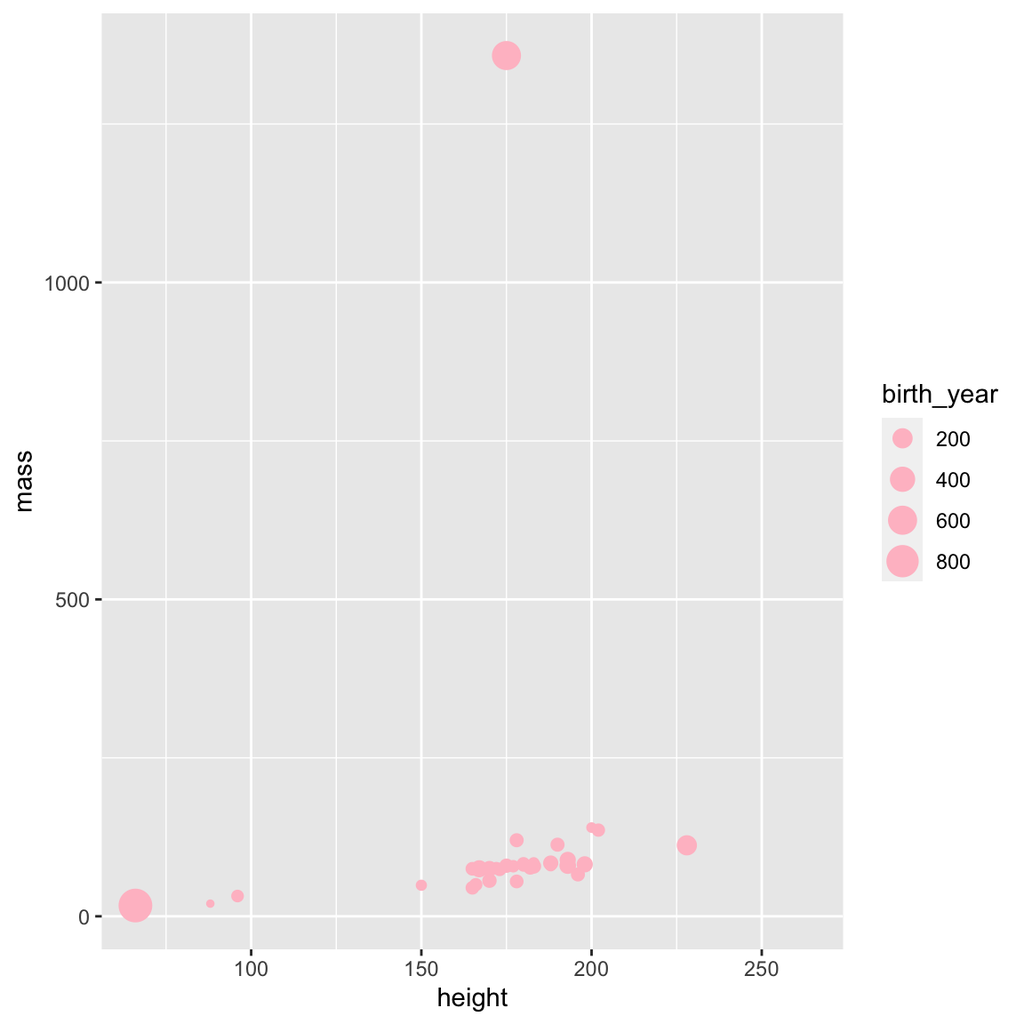

```r
ggplot(starwars,
       aes(x = height, y = mass, color = gender, size = birth_year)) +
  geom_point(color = "pink")
```

### Add labels for title, x and y axes, and size of points.

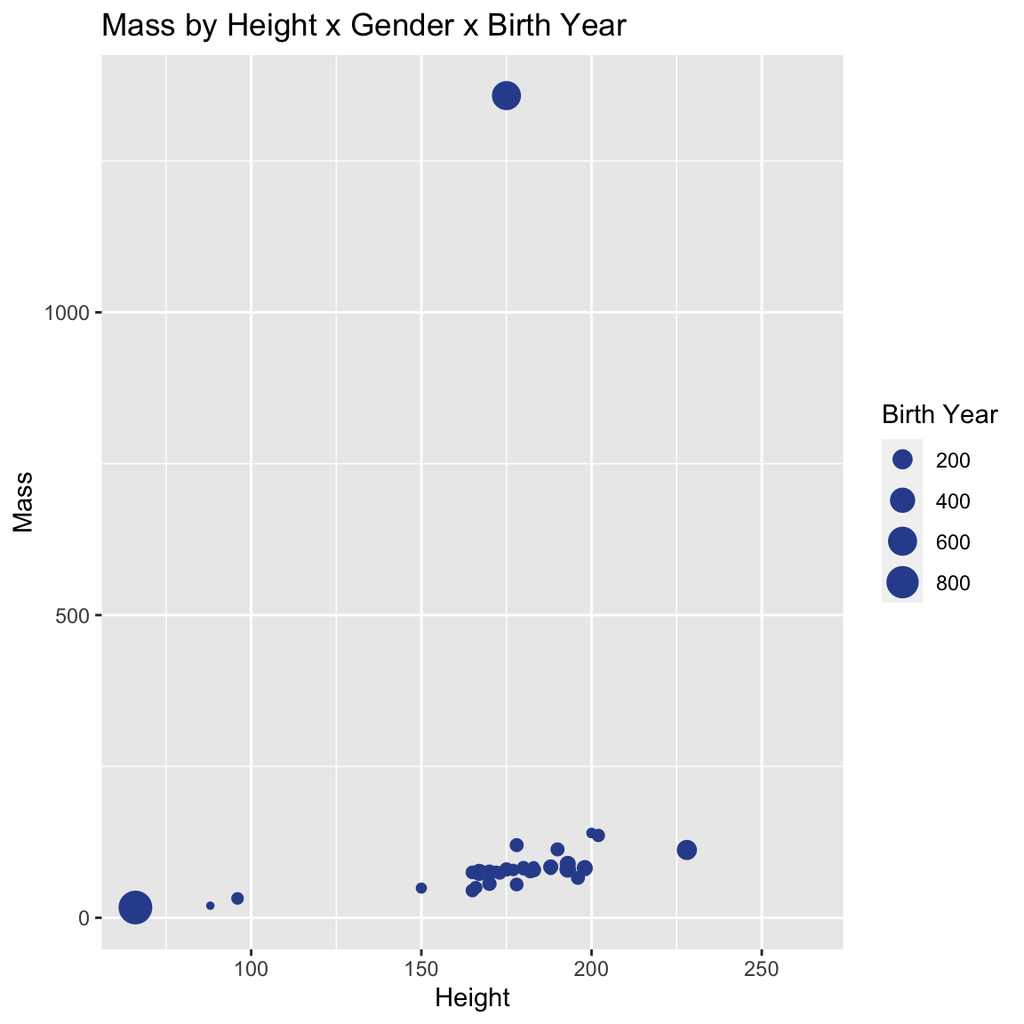

```r
library(viridis)
ggplot(starwars,
       aes(x = height, y = mass, color = gender, size = birth_year)) +
  geom_point(color = "#30509C") +
  labs(
    title = "Mass by Height x Gender x Birth Year",
    x = "Height",
    y = "Mass",
    size = "Birth Year"
    )
```

### Pick a single categorical variable from the data set and make a bar plot of its distribution.

```r
ggplot(starwars, aes(homeworld, fill = homeworld)) +
  geom_bar() +
  scale_fill_viridis_d(option = "mako") +
  guides(fill = "none") +
  theme_minimal() +
  coord_flip()
```

[output not shown]

### Pick a single numerical variable and make a histogram of it.

(This time no starter code is provided, you’re on your own!)

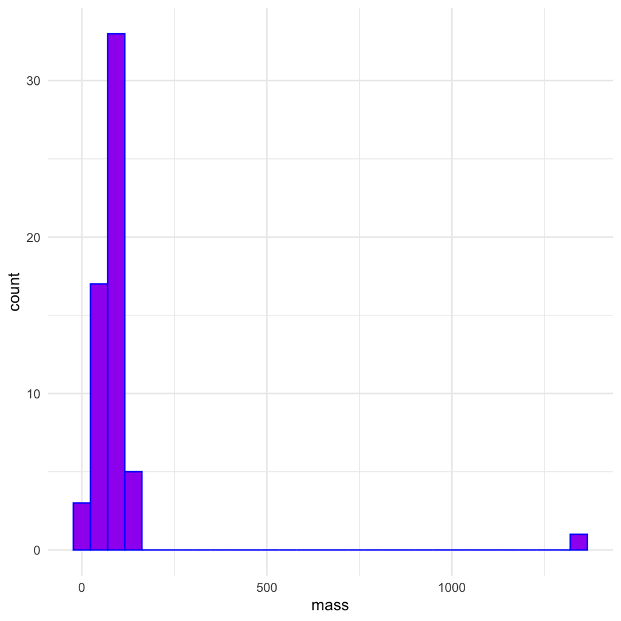

```r
ggplot(starwars, aes(mass)) +
  geom_histogram(color = "blue", fill = "purple") +
  theme_minimal()
```

### Pick a numerical variable and a categorical variable and make a visualisation (you pick the type!) to visualise the relationship between the two variables. Along with your code and output, provide an interpretation of the visualisation.

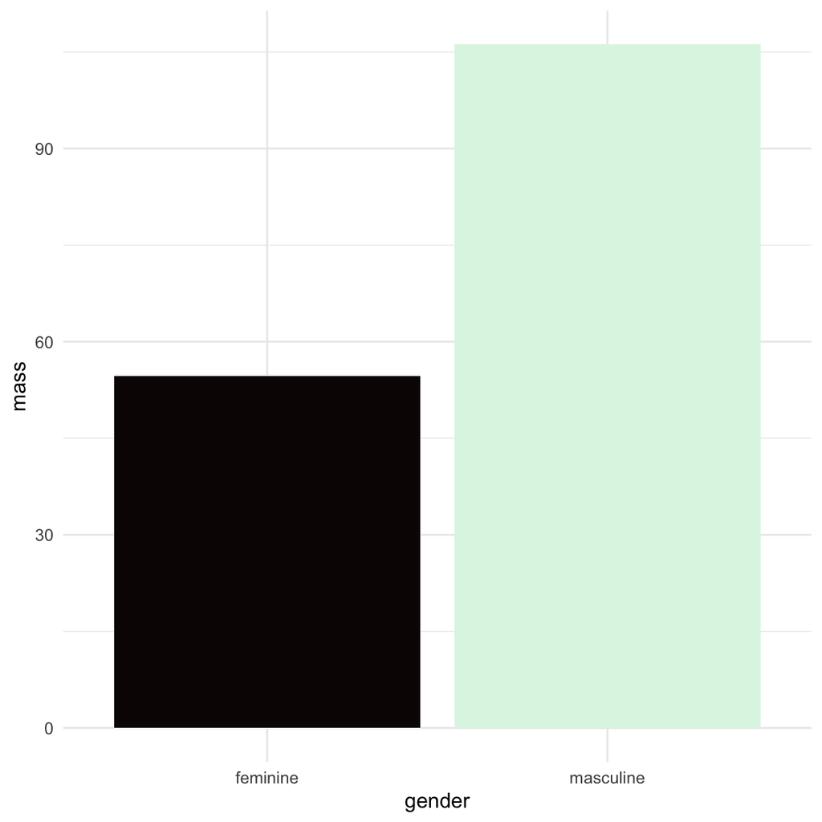

```r
ggplot(starwars %>% filter(!is.na(gender)), aes(x = gender, y = mass, fill = gender)) +
  stat_summary(geom = "bar", fun = "mean") +
  guides(fill = "none") +
  scale_fill_viridis_d(option = "mako") +
  theme_minimal()
```

### Pick two categorical variables and make a visualisation to visualise the relationship between the two variables. Along with your code and output, provide an interpretation of the visualisation.

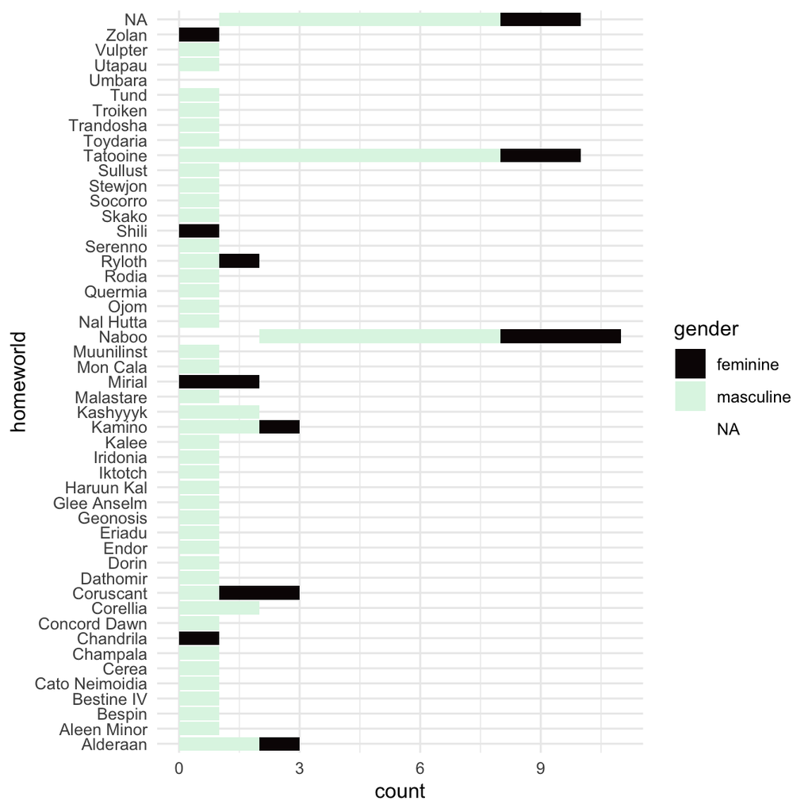

```r
ggplot(starwars, aes(homeworld, fill = gender)) +
  geom_bar() +
  scale_fill_viridis_d(option = "mako") +
  theme_minimal() +
  coord_flip()
```

# Hotels + Data Wrangling

```r
set.seed(8765)
hotels <- read_csv("https://raw.githubusercontent.com/rfordatascience/tidytuesday/master/data/2020/2020-02-11/hotels.csv") %>% sample_n(1000)
```

## Exercises

### Exercise 1.

Warm up! Take a look at an overview of the data with the `glimpse()` function.

**Note:** I already gave you the answer to this exercise.You only need to run the code and view the output. A definition of all variables is given in the Data dictionary section at the end, though you don’t need to familiarize yourself with all variables in order to work through these exercises.

```r
glimpse(hotels)
```

```
## Rows: 1,000
## Columns: 32
## $ hotel                          <chr> "City Hotel", "City Hotel", "City Hotel…
## $ is_canceled                    <dbl> 0, 1, 0, 1, 0, 0, 0, 1, 0, 1, 0, 1, 1, …
## $ lead_time                      <dbl> 49, 77, 43, 27, 451, 63, 256, 141, 6, 2…
## $ arrival_date_year              <dbl> 2015, 2017, 2016, 2015, 2017, 2015, 201…
## $ arrival_date_month             <chr> "November", "July", "November", "July",…
## $ arrival_date_week_number       <dbl> 46, 30, 46, 31, 28, 36, 25, 43, 45, 47,…
## $ arrival_date_day_of_month      <dbl> 9, 25, 11, 27, 12, 4, 15, 22, 1, 17, 7,…
## $ stays_in_weekend_nights        <dbl> 1, 0, 1, 1, 0, 0, 0, 2, 2, 0, 2, 0, 0, …
## $ stays_in_week_nights           <dbl> 2, 4, 2, 1, 3, 2, 2, 2, 1, 3, 2, 2, 3, …
## $ adults                         <dbl> 2, 2, 2, 2, 2, 2, 2, 2, 1, 2, 2, 2, 2, …
## $ children                       <dbl> 0, 1, 0, 0, 0, 0, 0, 0, 0, 0, 0, 0, 0, …
## $ babies                         <dbl> 0, 0, 0, 0, 0, 0, 0, 0, 0, 0, 0, 0, 0, …
## $ meal                           <chr> "BB", "SC", "BB", "BB", "BB", "HB", "HB…
```

[output cut: 19 more lines]

### Exercise 2.

Are people traveling on a whim? Let’s see…

Fill in the blanks for filtering for hotel bookings where the guest is **not** from the US (`country` code `"USA"`) and the `lead_time` is less than 1 day.

```r
hotels %>%
  filter(
    country != "USA",
    lead_time < 1
    )
```

```
## # A tibble: 55 × 32
##    hotel        is_canceled lead_time arrival_date_year arrival_date_month
##    <chr>              <dbl>     <dbl>             <dbl> <chr>
##  1 Resort Hotel           0         0              2016 February
##  2 Resort Hotel           0         0              2015 November
##  3 City Hotel             1         0              2016 December
##  4 Resort Hotel           0         0              2015 July
##  5 City Hotel             0         0              2016 April
##  6 Resort Hotel           0         0              2017 April
##  7 Resort Hotel           0         0              2017 August
##  8 Resort Hotel           0         0              2017 January
##  9 City Hotel             0         0              2016 June
## 10 Resort Hotel           0         0              2017 February
## # … with 45 more rows, and 27 more variables: arrival_date_week_number <dbl>,
## #   arrival_date_day_of_month <dbl>, stays_in_weekend_nights <dbl>,
## #   stays_in_week_nights <dbl>, adults <dbl>, children <dbl>, babies <dbl>,
## #   meal <chr>, country <chr>, market_segment <chr>,
## #   distribution_channel <chr>, is_repeated_guest <dbl>,
## #   previous_cancellations <dbl>, previous_bookings_not_canceled <dbl>,
## #   reserved_room_type <chr>, assigned_room_type <chr>, …
```

### Exercise 3.

How many bookings involve at least 1 child **or** baby?

In the following chunk, replace

- `[AT LEAST]` with the logical operator for “at least” (in two places)
- `[OR]` with the logical operator for “or”

```r
hotels %>%
  filter(
    children >= 1 | babies >= 1
    )
```

```
## # A tibble: 82 × 32
##    hotel        is_canceled lead_time arrival_date_year arrival_date_month
##    <chr>              <dbl>     <dbl>             <dbl> <chr>
##  1 City Hotel             1        77              2017 July
##  2 Resort Hotel           0       179              2017 April
##  3 City Hotel             1        79              2016 May
##  4 City Hotel             0        18              2017 August
##  5 Resort Hotel           0        43              2017 March
##  6 Resort Hotel           0         4              2016 February
##  7 Resort Hotel           0         4              2017 August
##  8 City Hotel             1        56              2017 March
##  9 Resort Hotel           1       198              2017 August
## 10 City Hotel             0         4              2017 February
## # … with 72 more rows, and 27 more variables: arrival_date_week_number <dbl>,
## #   arrival_date_day_of_month <dbl>, stays_in_weekend_nights <dbl>,
## #   stays_in_week_nights <dbl>, adults <dbl>, children <dbl>, babies <dbl>,
## #   meal <chr>, country <chr>, market_segment <chr>,
## #   distribution_channel <chr>, is_repeated_guest <dbl>,
## #   previous_cancellations <dbl>, previous_bookings_not_canceled <dbl>,
## #   reserved_room_type <chr>, assigned_room_type <chr>, …
```

### Exercise 4.

Do you think it’s more likely to find bookings with children or babies in city hotels or resort hotels? Test your intuition. Using `filter()` determine the number of bookings in resort hotels that have more than 1 child **or** baby in the room? Then, do the same for city hotels, and compare the numbers of rows in the resulting filtered data frames.

```r
hotels %>%
  filter(hotel == "Resort Hotel") %>%
  filter(children > 1 | babies > 1) %>%
  count()
```

```
## # A tibble: 1 × 1
##       n
##   <int>
## 1    14
```

```r
hotels %>%
  filter(hotel == "City Hotel") %>%
  filter(children > 1 | babies > 1) %>%
  count()
```

```
## # A tibble: 1 × 1
##       n
##   <int>
## 1    19
```

### Exercise 5.

Create a frequency table of the number of `adults` in a booking. Display the results in descending order so the most common observation is on top. What is the most common number of adults in bookings in this dataset? Are there any surprising results?

```r
hotels %>%
  count(adults, sort = TRUE)
```

```
## # A tibble: 4 × 2
##   adults     n
##    <dbl> <int>
## 1      2   743
## 2      1   192
## 3      3    58
## 4      0     7
```

### Exercise 6.

Repeat Exercise 5, once for canceled bookings (`is_canceled` coded as 1) and once for not canceled bookings (`is_canceled` coded as 0). What does this reveal about the surprising results you spotted in the previous exercise?

```r
hotels %>%
  filter(is_canceled == 1) %>%
  count(adults, sort = TRUE)
```

```
## # A tibble: 4 × 2
##   adults     n
##    <dbl> <int>
## 1      2   286
## 2      1    51
## 3      3    30
## 4      0     3
```

```r
hotels %>%
  filter(is_canceled == 0) %>%
  count(adults, sort = TRUE)
```

```
## # A tibble: 4 × 2
##   adults     n
##    <dbl> <int>
## 1      2   457
## 2      1   141
## 3      3    28
## 4      0     4
```

### Exercise 7.

Calculate minimum, mean, median, and maximum average daily rate (`adr`) grouped by `hotel` type so that you can get these statistics separately for resort and city hotels. Which type of hotel is higher, on average?

```r
hotels %>%
  group_by(hotel) %>%
  summarize(`Mean ADR` = mean(adr, na.rm = TRUE),
            `Median ADR` = median(adr, na.rm = TRUE),
            `Min ADR` = min(adr, na.rm = TRUE),
            `Max ADR` = max(adr, na.rm = TRUE))
```

```
## # A tibble: 2 × 5
##   hotel        `Mean ADR` `Median ADR` `Min ADR` `Max ADR`
##   <chr>             <dbl>        <dbl>     <dbl>     <dbl>
## 1 City Hotel        104.         100           0       258
## 2 Resort Hotel       95.7         78.9         0       271
```

## Data dictionary

Below is the full data dictionary. Note that it is long (there are lots of variables in the data), but we will be using a limited set of the variables for our analysis.

| variable | class | description |
| --- | --- | --- |
| hotel | character | Hotel (H1 = Resort Hotel or H2 = City Hotel) |
| is_canceled | double | Value indicating if the booking was canceled (1) or not (0) |
| lead_time | double | Number of days that elapsed between the entering date of the booking into the PMS and the arrival date |
| arrival_date_year | double | Year of arrival date |
| arrival_date_month | character | Month of arrival date |
| arrival_date_week_number | double | Week number of year for arrival date |
| arrival_date_day_of_month | double | Day of arrival date |
| stays_in_weekend_nights | double | Number of weekend nights (Saturday or Sunday) the guest stayed or booked to stay at the hotel |
| stays_in_week_nights | double | Number of week nights (Monday to Friday) the guest stayed or booked to stay at the hotel |
| adults | double | Number of adults |
| children | double | Number of children |
| babies | double | Number of babies |
| meal | character | Type of meal booked. Categories are presented in standard hospitality meal packages: Undefined/SC – no meal package; BB – Bed & Breakfast; HB – Half board (breakfast and one other meal – usually dinne… |
| country | character | Country of origin. Categories are represented in the ISO 3155–3:2013 format |
| market_segment | character | Market segment designation. In categories, the term “TA” means “Travel Agents” and “TO” means “Tour Operators” |
| distribution_channel | character | Booking distribution channel. The term “TA” means “Travel Agents” and “TO” means “Tour Operators” |
| is_repeated_guest | double | Value indicating if the booking name was from a repeated guest (1) or not (0) |
| previous_cancellations | double | Number of previous bookings that were cancelled by the customer prior to the current booking |
| previous_bookings_not_canceled | double | Number of previous bookings not cancelled by the customer prior to the current booking |
| reserved_room_type | character | Code of room type reserved. Code is presented instead of designation for anonymity reasons |
| assigned_room_type | character | Code for the type of room assigned to the booking. Sometimes the assigned room type differs from the reserved room type due to hotel operation reasons (e.g. overbooking) or by customer request. Code i… |
| booking_changes | double | Number of changes/amendments made to the booking from the moment the booking was entered on the PMS until the moment of check-in or cancellation |
| deposit_type | character | Indication on if the customer made a deposit to guarantee the booking. This variable can assume three categories: No Deposit – no deposit was made; Non Refund – a deposit was made in the value of the … |
| agent | character | ID of the travel agency that made the booking |
| company | character | ID of the company/entity that made the booking or responsible for paying the booking. ID is presented instead of designation for anonymity reasons |
| days_in_waiting_list | double | Number of days the booking was in the waiting list before it was confirmed to the customer |
| customer_type | character | Type of booking, assuming one of four categories: Contract - when the booking has an allotment or other type of contract associated to it; Group – when the booking is associated to a group; Transient … |
| adr | double | Average Daily Rate as defined by dividing the sum of all lodging transactions by the total number of staying nights |
| required_car_parking_spaces | double | Number of car parking spaces required by the customer |
| total_of_special_requests | double | Number of special requests made by the customer (e.g. twin bed or high floor) |
| reservation_status | character | Reservation last status, assuming one of three categories: Canceled – booking was canceled by the customer; Check-Out – customer has checked in but already departed; No-Show – customer did not check-i… |
| reservation_status_date | double | Date at which the last status was set. This variable can be used in conjunction with the ReservationStatus to understand when was the booking canceled or when did the customer checked-out of the hotel |

## References

1. Mine Çetinkaya-Rundel; Creator